# STATS506_hw3

Author

Xingjian Liu

```r
knitr::opts_chunk$set(error=TRUE)
```

GitHub: https://github.com/CherryLIUxj/STATS506_proj/tree/master

# Problem 1 - Vision

## a. Merge the two files to create a single Stata dataset, using the **SEQN** variable for merging. Keep only records which matched. Print our your total sample size, showing that it is now 6,980.

Download the file VIX_D from [this location](http://wwwn.cdc.gov/nchs/nhanes/search/datapage.aspx?Component=Examination&CycleBeginYear=2005), and determine how to read it into Stata. Then download the file DEMO_D from [this location](http://wwwn.cdc.gov/Nchs/Nhanes/Search/DataPage.aspx?Component=Demographics&CycleBeginYear=2005). Note that each page contains a link to a documentation file for that data set.

```r
// a. import and merge two datasets
. ssc install usesas, replace

. import sasxport5 "/Users/liuxingjian/Documents/Stata/VIX_D.XPT"
. save vix_d.dta, replace

. clear

. import sasxport5 "/Users/liuxingjian/Documents/Stata/DEMO_D.XPT"
. save demo_d.dta, replace

. clear

. use vix_d.dta
. merge 1:1 seqn using demo_d.dta

. count
. codebook _merge
. keep if _merge==3
. count
```

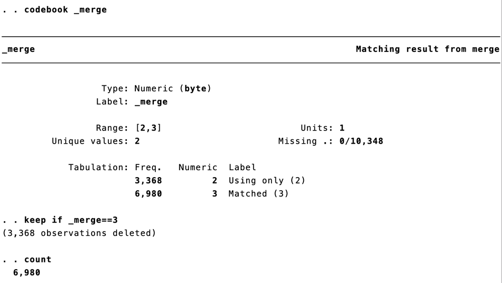

## b. Without fitting any models, estimate the proportion of respondents within each 10-year age bracket (e.g. 0-9, 10-19, 20-29, etc) who wear glasses/contact lenses for distance vision. Produce a nice table with the results.

```r
//b.
// VIQ220 - Glasses/contact lenses worn for distance (1,2,9,.)
// RIDAGEYR - Age at Screening Adjudicated (0-85)

. egen age = cut(ridageyr), at(0(10)90)
// age ranges from 12 to 85, none under 10

. gen viq220_1 = (viq220==1)
// generate this variable for collapse afterwards
```

```r
. preserve
// because collapse is destructive

. collapse (count) all=seqn (sum) wear=(viq220_1), by (age)
. gen wear_rate = wear/all
. list
. save ifdistance_wear

. restore
```

```
Error: <text>:1:3: unexpected symbol
1: . preserve
      ^
```

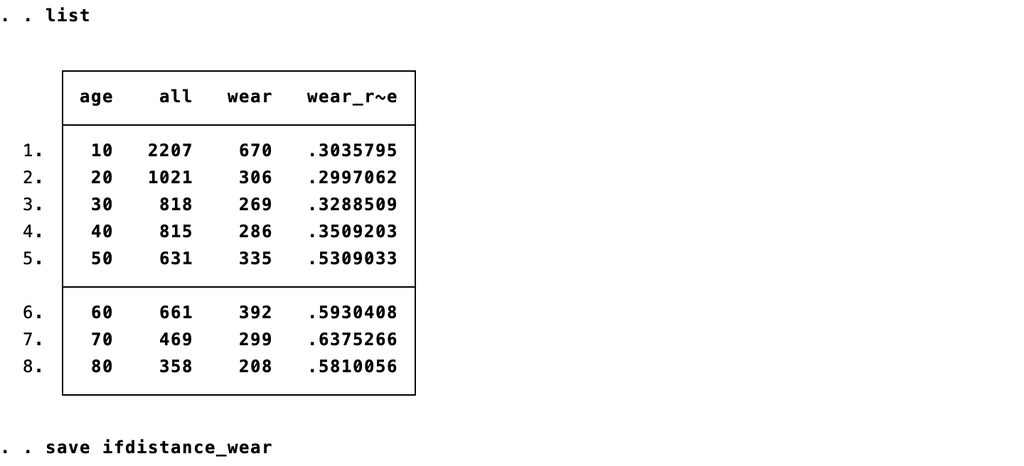

wear_rate is the proportion of respondents who wear glasses/contact lenses for distant version

## c. Fit three logistic regression models predicting whether a respondent wears glasses/contact lenses for distance vision.

Predictors:

1. age
2. age, race, gender
3. age, race, gender, Poverty Income ratio

Produce a table presenting the estimated odds ratios for the coefficients in each model, along with the sample size for the model, the pseudo-r2, and AIC values.

```r
//c.
// age: RIDAGEYR; race: RIDRETH1; gender:RIAGENDR; poverty income ratio: INDFMPIR
// logit will handle missing values itself by simply drop the entries (missing values: denoted by '.')

. preserve

. keep if viq220==1 | viq220==2
// drop missing values and "Don't know" values

. replace viq220=0 if viq220==2
// transform viq220 to 0/1

. replace riagendr=0 if riagendr==2
// transform gender to 0/1
```

```r
// model 1
. logistic viq220 ridageyr
. estat ic

// model 2
. logistic viq220 ridageyr i.ridreth1 i.riagendr
. estat ic

// model 3
. logistic viq220 ridageyr i.ridreth1 i.riagendr indfmpir
. estat ic
```

```r
. matrix models=J(3,10,.)
. matrix rownames models='wear~age' 'wear~age+race+gender' 'wear~age+race+gender+pir'
. matrix colnames models='or_age' 'or_race2' 'or_race3' 'or_race4' 'or_race5' 'or_gender' 'or_pir' 'sample_size' 'pseudo_r2' 'aic'
. matrix models[1,1]=1.02498
. matrix models[1,8]=6545
. matrix models[1,9]=0.0497
. matrix models[1,10]=8489.46
. matrix models[2,1]=1.022831
. matrix models[2,2]=1.169203
. matrix models[2,3]=1.952149
. matrix models[2,4]=1.29936
. matrix models[2,5]=1.917442
. matrix models[2,6]=0.6052646
. matrix models[2,8]=6545
. matrix models[2,9]=0.0720
. matrix models[2,10]=8287.761
. matrix models[3,1]=1.022436
. matrix models[3,2]=1.123021
. matrix models[3,3]=1.651244
. matrix models[3,4]=1.230456
. matrix models[3,5]=1.703572
. matrix models[3,6]=0.5967415
. matrix models[3,7]=1.120301
. matrix models[3,8]=6247
. matrix models[3,9]=0.0734
. matrix models[3,10]=7909.808
. matrix list models
```

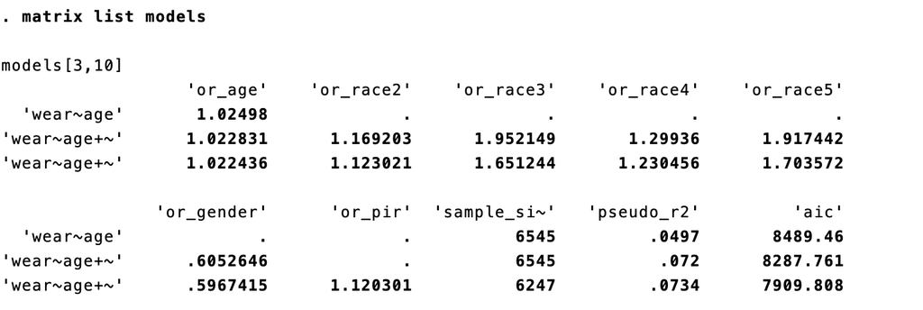

## d. From the third model from the previous part, discuss whether the *odds* of men and women being wears of glasess/contact lenses for distance vision differs. Test whether the *proportion* of wearers of glasses/contact lenses for distance vision differs between men and women. Include the results of the test and its interpretation.

```r
. tabulate viq220 riagendr, chi2
```

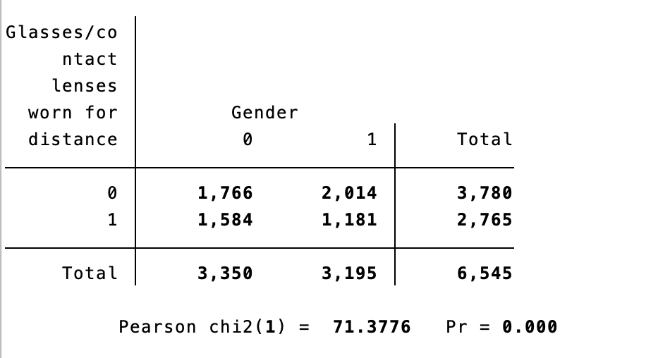

From the chi-square distribution above, we can see that the **number** of wearers differs between genders. And because the **number** differs, we can conclude that the **proportion** differs as well since proportion of wearers is (number of wears) / (number of respondents).

# Problem 2 - **Sakila**

```r
install.packages('RSQLite')
```

```
Error in contrib.url(repos, "source"): trying to use CRAN without setting a mirror
```

```r
library(DBI)
```

```r
sakila <- dbConnect(RSQLite::SQLite(), "sakila_master.db")
sakila
```

```
<SQLiteConnection>
  Path: /Users/liuxingjian/Desktop/刘行健/umich课程/stats 506/homework/hw3/sakila_master.db
  Extensions: TRUE
```

```r
dbListTables(sakila)
```

```
 [1] "actor"                  "address"                "category"
 [4] "city"                   "country"                "customer"
 [7] "customer_list"          "film"                   "film_actor"
[10] "film_category"          "film_list"              "film_text"
[13] "inventory"              "language"               "payment"
[16] "rental"                 "sales_by_film_category" "sales_by_store"
[19] "staff"                  "staff_list"             "store"
```

## a. Aside from English, what language is most common for films? Answer this with a single SQL query

```r
dbListFields(sakila,"film")
```

```
 [1] "film_id"              "title"                "description"
 [4] "release_year"         "language_id"          "original_language_id"
 [7] "rental_duration"      "rental_rate"          "length"
[10] "replacement_cost"     "rating"               "special_features"
[13] "last_update"
```

```r
dbListFields(sakila,"language")
```

```
[1] "language_id" "name"        "last_update"
```

```r
dbGetQuery(sakila,'select name from film inner join language using (language_id) group by name order by count(*)')
```

```
     name
1 English
```

It appears that there are only English films.

## b. What genre of movie is the most common in the data, and how many movies are of this genre?

### SQL+R:

```r
dbListFields(sakila,'category')
```

```
[1] "category_id" "name"        "last_update"
```

```r
film_categoryName <- dbGetQuery(sakila,'select name from category join film_category using (category_id)')
```

```r
freq_table <- table(film_categoryName$name)
which(freq_table==max(freq_table))
```

```
Sports
    15
```

```r
max(freq_table)
```

```
[1] 74
```

### Pure SQL

```r
dbGetQuery(sakila,'select name, count(*) as count from category join film_category using (category_id) group by name order by count desc limit 1')
```

```
    name count
1 Sports    74
```

Sports is the most common genre. Total of 74 Sports movies in collection.

## c. Identify which country or countries have exactly 9 customers. Answer this with a single SQL query.

```r
dbGetQuery(sakila,'select count(distinct customer_id) as customer_count,country_id,country
from country
join city using (country_id)
join address using (city_id)
join customer using (address_id)
group by country_id
having customer_count=9')
```

```
  customer_count country_id        country
1              9        102 United Kingdom
```

It is UK that has exactly 9 customers.

# Problem 3 **- US Records**

```r
records <- read.csv('us-500.csv')
head(records)
```

```
  first_name last_name           company_name              address        city
1      James      Butt      Benton, John B Jr   6649 N Blue Gum St New Orleans
2  Josephine   Darakjy  Chanay, Jeffrey A Esq  4 B Blue Ridge Blvd    Brighton
3        Art    Venere    Chemel, James L Cpa 8 W Cerritos Ave #54  Bridgeport
4      Lenna  Paprocki Feltz Printing Service          639 Main St   Anchorage
5    Donette    Foller    Printing Dimensions         34 Center St    Hamilton
6     Simona   Morasca    Chapman, Ross E Esq         3 Mcauley Dr     Ashland
      county state   zip       phone1       phone2
1    Orleans    LA 70116 504-621-8927 504-845-1427
2 Livingston    MI 48116 810-292-9388 810-374-9840
3 Gloucester    NJ  8014 856-636-8749 856-264-4130
4  Anchorage    AK 99501 907-385-4412 907-921-2010
5     Butler    OH 45011 513-570-1893 513-549-4561
6    Ashland    OH 44805 419-503-2484 419-800-6759
                          email                                 web
1               jbutt@gmail.com        http://www.bentonjohnbjr.com
2 josephine_darakjy@darakjy.org    http://www.chanayjeffreyaesq.com
3                art@venere.org      http://www.chemeljameslcpa.com
4         lpaprocki@hotmail.com http://www.feltzprintingservice.com
5        donette.foller@cox.net   http://www.printingdimensions.com
6            simona@morasca.com      http://www.chapmanrosseesq.com
```

## a. What proportion of email addresses are hosted at a domain with TLD ".net"? (E.g. in the email, "angrycat@freemail.org", "freemail.org" is the domain, with TLD (top-level domain) ".org".)

```r
length(grep('.net$',records$email))/length(records$email)
```

```
[1] 0.14
```

## b. What proportion of email addresses have at least one non alphanumeric character in them?

```r
length(grep("[^a-zA-Z0-9].*@",records$email))/length(records$email)
```

```
[1] 0.506
```

## c. What is the most common area code amongst all phone numbers?

```r
all_phone <- unique(c(records$phone1,records$phone2))
length(all_phone)
```

```
[1] 1000
```

```r
# phone1 phone2 no overlaps
```

```r
table_areaCode <- table(sapply(all_phone,function(x) substr(x,1,3)))
which(table_areaCode==max(table_areaCode))
```

```
973
158
```

The most common area code is ‘973’

## d. Produce a histogram of the log of the apartment numbers for all addresses. (You may assume any number after the street is an apartment number.)

the number after “#” is apartment number

```r
has_apt <- records$address[grep('#',records$address)]
length(has_apt)
```

```
[1] 109
```

```r
list_adr_apt <- strsplit(has_apt, "#")
list_adr_apt[[1]][2]
```

```
[1] "54"
```

```r
apt <- c()
for (i in 1:length(has_apt)){
  apt <- c(apt,as.integer(list_adr_apt[[i]][2]))
}
apt
```

```
  [1]   54   88 2808   69 8673   84    1 6101    9 4121  615   53  679 1995 9230
 [16]  950  316  900    2  840 1153  647 8581    9    7  835    3   45  525   86
 [31] 5435 6327  914  722 6496    9  106    3  197  492   42   32    7    7  916
 [46]  590 3224   75   46    7  227    9    1 1438  449  822   90   60    4   42
 [61]   82   79 3519  799 9759  372    3 4462 2804    2 7913   91    9   33    8
 [76]   92 9851 5410   38    2   63  500  598    9   54  779    1  588 7073    2
 [91] 2824  563  146    1   22  595   72 8343  508  403 3849    3   43   52  979
[106]   29    6    1    2
```

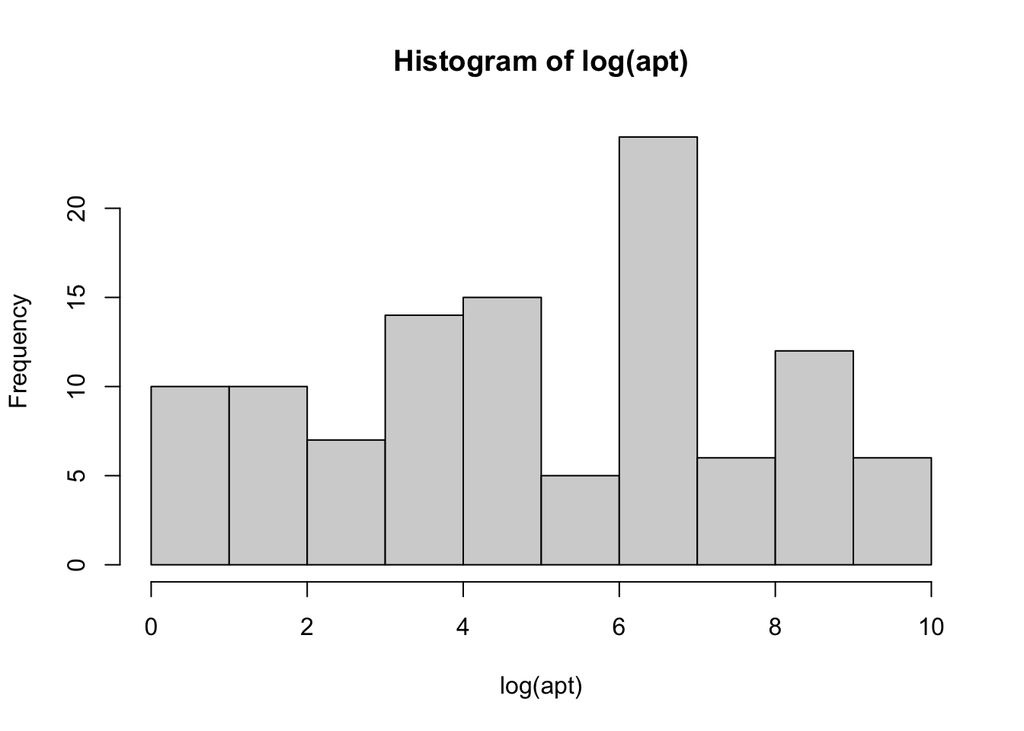

```r
hist(log(apt))
```

## e. [Benford's law](https://en.wikipedia.org/wiki/Benford's_law) is an observation about the distribution of the leading digit of real numerical data. Examine whether the apartment numbers appear to follow Benford's law. Do you think the apartment numbers would pass as real data?

```r
max_first_count <- 0
for (i in 0:9){
  format <- paste('^',as.character(i),sep='')
  first_count <- length(grep(format,apt))
  if (max_first_count < first_count){
    max_first_digit <- i
    max_first_count <- first_count}
}
```

```r
max_first_digit
```

```
[1] 9
```

So we can say the apartment numbers don’t pass as real data.

## f. Repeat your analysis of Benford's law on the *last* digit of the street number. (E.g. if your address is "123 Main St #25", your street number is "123".)

```r
records$address[1:10]
```

```
 [1] "6649 N Blue Gum St"    "4 B Blue Ridge Blvd"   "8 W Cerritos Ave #54"
 [4] "639 Main St"           "34 Center St"          "3 Mcauley Dr"
 [7] "7 Eads St"             "7 W Jackson Blvd"      "5 Boston Ave #88"
[10] "228 Runamuck Pl #2808"
```

```r
list_adr_st <- strsplit(records$address, " ")
list_adr_st[[1]][1]
```

```
[1] "6649"
```

```r
st <- c()
for (i in 1:length(list_adr_st)){
  st <- c(st,as.integer(list_adr_st[[i]][1]))
}
```

```r
max_last_count <- 0
for (i in 0:9){
  format <- paste(as.character(i),'$',sep='')
  last_count <- length(grep(format,st))
  if (max_last_count < last_count){
    max_last_digit <- i
    max_last_count <- last_count}
}
```

```r
max_last_digit
```

```
[1] 9
```